# ANEXO 2

### 3.6.2 Precio por m2 y tipo vendedor (1=particular, 2=inmobiliaria)

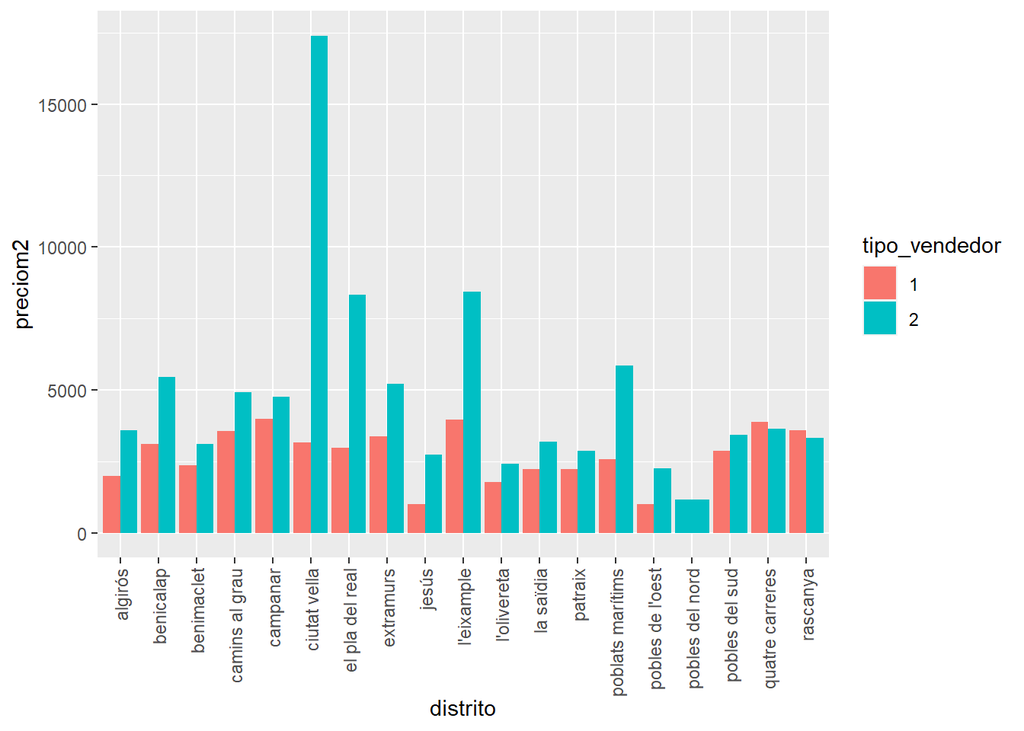

```r
ggplot(vendImp, aes(x=distrito, y=preciom2, fill=tipo_vendedor)) +
  geom_col(position = "dodge") + theme(axis.text.x =
  element_text(angle = 90, vjust = 0.5, hjust=1))
```

# 4 MATRIZ DE CORRELACIÓN

## 4.1 Entre variables numéricas

Para ver si nuestras variables numéricas tienen correlación, vamos a hacer una matriz de correlación. También, vamos calcular su P-valor para determinar si dicha correlación es significativa o no.

```r
library(corrplot)
library (Hmisc)
vendCor = vendImp[,c("baños", "m2", "habitaciones", "planta",
                      "precio_final", "variacion_precio", "dias_venta",
                     "preciom2")]
cor = cor(vendCor)
c = rcorr(as.matrix(vendCor),type="pearson")
c1 = c[['r']]
c2 = c[['P']] #p-value
kable(c1, format="latex", booktabs = T) %>% kable_styling(font_size = 8)
```

```r
kable(c2, format="latex", booktabs = T) %>% kable_styling(font_size = 8)
```

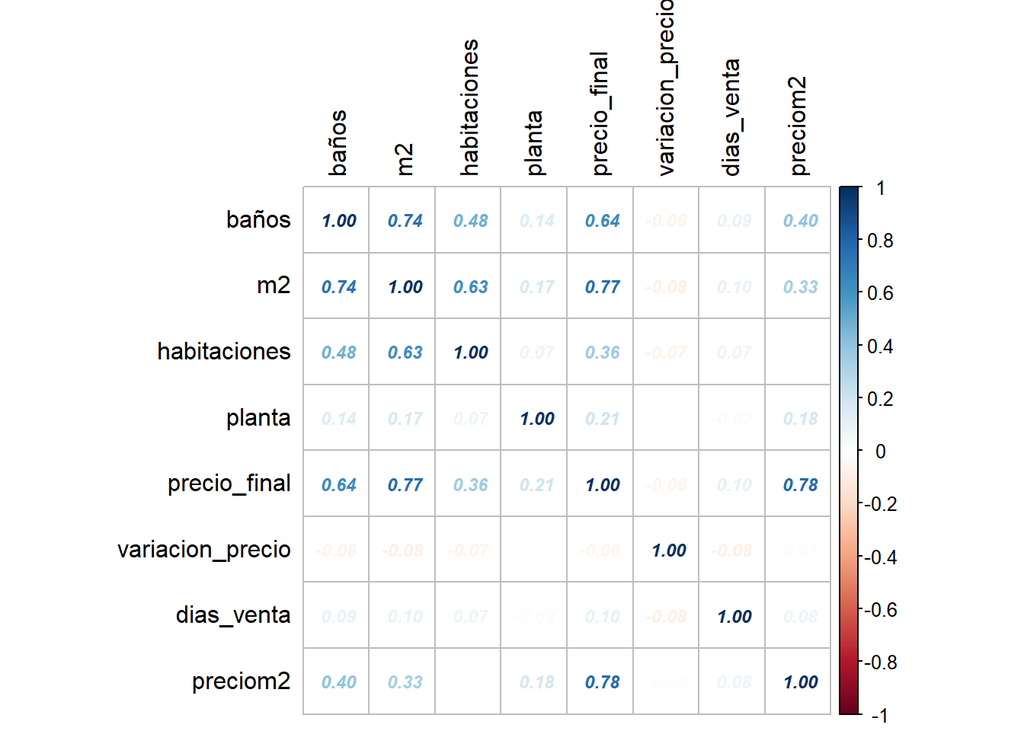

```r
corrplot(cor, method = 'number', number.font = 4,
         tl.col = 'black', number.cex = 0.75)
```

## 4.2 Entre variables binarias

Ahora, se vuelve a calcular las correlaciones (con una matriz de correlación) entre las variables binarias de la BD.

```r
library(corrplot)
library (Hmisc)
vendCor = vendImp[,c("jardin", "ascensor", "piscina", "terraza",
"a_reformar", "armarios.empotrados", "acceso.adaptado",
"aire.acondicionado", 'balcon', 'trastero', 'garaje.incluido',
'calefaccion')]
index = 1:ncol(vendCor)
vendCor[, index] = lapply(vendCor[, index], as.numeric)
cor = cor(vendCor)
c = rcorr(as.matrix(vendCor),type="pearson")
c1 = c[['r']]
c2 = c[['P']] #p-value
kable(c1, format="latex", booktabs = T) %>%
  kable_styling(font_size = 8)
```

```r
kable(c2, format="latex", booktabs = T) %>%
  kable_styling(font_size = 8)
```

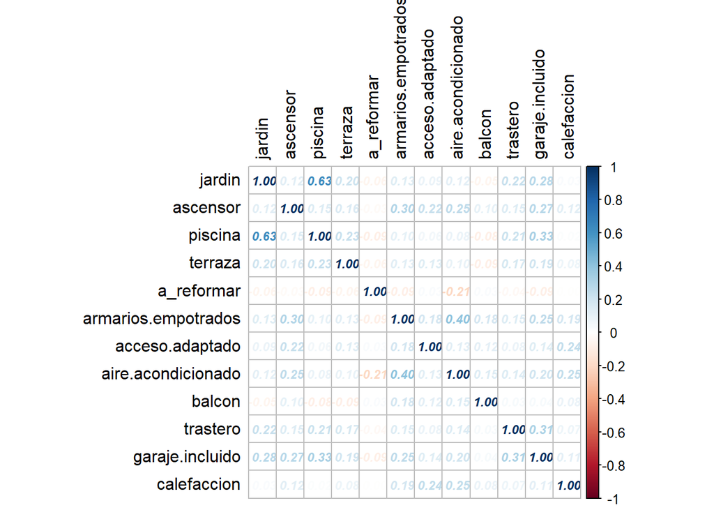

```r
corrplot(cor, method = 'number', number.font = 4, tl.col = 'black',
         number.cex = 0.75)
```

# 5 BD DISTRITOS_INFO

## 5.1 Lectura datos

```r
valencia = read.csv('valencia.csv', sep=";", row.names = 1, as.is=TRUE, encoding='UTF-8')
locales = read.csv("localesR.csv", sep=";", row.names=1, as.is=TRUE, encoding='UTF-8')
```

## 5.2 Análisis exploratorio y limpieza

```r
# eliminar variables sin información sobre metros construidos
valencia = valencia[!is.na(valencia$ad_characteristics_constructedArea),]

valencia2 = valencia[,setdiff(colnames(valencia),
                             c("ad_condition_isGoodCondition", "ad_typology",
                               "ad_operation",  "address_location",
                               "date_insert", "date_update", "latitude",
                               "longitude", "price", "url", "date_last",
                               "features" ,"day_insert", "day_last",
                               "vendido", "ad_characteristics_hasParking"))]

colnames(valencia2)= c('baños', 'm2', 'jardin', 'ascensor', 'piscina',
                      'terraza', 'habitaciones', 'a_reformar',
                      'tipo_vendedor', 'precio_final',
                      'distrito', 'barrio', "armarios.empotrados",
                      "acceso.adaptado", "aire.acondicionado", "balcon",
                      "trastero", "garaje.incluido", "calefaccion",
                      "planta", "vistas", "variacion_precio", "dias_venta")

# a binarias: vistas (interior = 0, exterior = 1)
valencia2$vistas[valencia2$vistas == 'exterior'] = 1
valencia2$vistas[valencia2$vistas == 'interior'] = 0
valencia2$vistas[valencia2$vistas == ''] = NA
valencia2$vistas[valencia2$vistas == 'TRUE'] = NA
valencia2$vistas[valencia2$vistas == 'FALSE'] = NA

valencia2$dias_venta = gsub(" days", "", valencia2$dias_venta)
valencia2 = transform(valencia2, dias_venta = as.numeric(dias_venta))

# Ponemos a 0 los días_venta a aquellos pisos que tengan días negativos
valencia2$dias_venta[valencia2$dias_venta < 0] = 0

#Variable baños
nulos = which(valencia2$baños==0)
valencia2$baños[valencia$baños== 41] = 1
valencia2 = valencia2[-nulos, ]

#Variable habitaciones
quitar = which(valencia2$habitaciones == 0)
valencia2 = valencia2[-quitar, ]
```

## 5.3 Valores faltantes. Imputación

Ahora, vamos a imputar, con la librería mice(), las variables que tengan algún valor faltante.

```r
library(mice)

val = valencia2
val$vistas = as.factor(val$vistas)
valImp = mice(val, seed = 123, m = 5, print = FALSE, method = NULL)
#head(vendImp$imp$vistas)
valImp = complete(valImp) #Complete a data frame with missing combinations of data
```

## 5.4 Preparación de la BD. Información agrupada por distritos

FILAS: los 19 distritos valencianos con los que estamos trabajando. COLUMNAS: información relativa a los distritos, sacada mediante la agrupación y ponderación de sus pisos.

Es **importante** recalcar que la información “estática” de un piso (número medio de habitaciones, porcentaje de pisos con piscina, jardín, balcón, etc.) se ha obtenido del total de pisos en el portal de Idealista.com (archivo valencia.csv). Sin embargo, las variables relativas a precio o a los días de venta, se han calculado con la base de datos viviendas_vendidas.csv (pisos que ya se han vendido)

```r
#CREAMOS LAS FILAS PARA DISTRITO (agrupación por distrito):
auxi = valImp %>% group_by(distrito)  %>%
                    summarise(num_pisos=n(),
                              media_m2 = mean(m2),
                              media_planta = mean(planta),
                              media_hab = mean(habitaciones),
                              media_baños = mean(baños),
                              porc_inmobiliaria=sum(tipo_vendedor==2)/num_pisos*100,
                              porc_parking=sum(garaje.incluido==1)/n()*100,
                              porc_ascensor=sum(ascensor==1)/n()*100,
                              porc_piscina=sum(piscina==1)/n()*100,
                              porc_terraza=sum(terraza==1)/n()*100,
                              porc_jardin=sum(jardin==1)/n()*100,
                              porc_reformar = round((sum(a_reformar==1)*100)/n(),2),
                              porc_arm = sum(armarios.empotrados==1)/n()*100,
                              porc_acceso = sum(acceso.adaptado==1)/n()*100,
                              porc_aire = sum(aire.acondicionado==1)/n()*100,
                              porc_balcon = sum(balcon==1)/n()*100,
                              porc_trastero = sum(trastero==1)/n()*100,
                              porc_calef = sum(calefaccion==1)/n()*100,
                              porc_exter = sum(vistas==1)/n()*100)
```

```r
library(arules)
m = valImp$m2
valImp$m2class = discretize(m, method='frequency', breaks=6, labels=c('30-70', '71-86', '87-99', '100-118', '119-148', '149-750'))


# FRECUENCIA DE VIVIENDAS POR RANGO DE M2 EN CADA DISTRITO
# obtenemos la información por rango
rango1 = data.frame(table(valImp$distrito[valImp$m2class == '30-70']))
rango2 = data.frame(table(valImp$distrito[valImp$m2class == '71-86']))
rango3 = data.frame(table(valImp$distrito[valImp$m2class == '87-99']))
rango4 = data.frame(table(valImp$distrito[valImp$m2class == '100-118']))
rango5 = data.frame(table(valImp$distrito[valImp$m2class == '119-148']))
rango6 = data.frame(table(valImp$distrito[valImp$m2class == '149-750']))
numero = data.frame(table(valImp$distrito)) # total

numero1 = data.frame(rango1)
numero2 = data.frame(rango2)
numero3 = data.frame(rango3)
numero4 = data.frame(rango4)
numero5 = data.frame(rango5)
numero6 = data.frame(rango6)

f = merge(x = numero, y = numero1, by = 'Var1', all = TRUE)
i = merge(x = f, y = numero2, by = 'Var1', all = TRUE)
colnames(numero3) = c('Var1', 'f')
n = merge(x = i, y = numero3, by = 'Var1', all =TRUE)
colnames(numero4) = c('Var1', 'f2')
a = merge(x = n, y = numero4, by = 'Var1', all = TRUE)
colnames(numero5) = c('Var1', 'f3')
l = merge(x = a, y = numero5, by = 'Var1', all = TRUE)
colnames(numero6) = c('Var1', 'f4')
final = merge(x = l, y = numero6, by = 'Var1', all = TRUE)

colnames(final) = c('distrito','total', '30-70', '71-86', '87-99', '100-118', '119-148', '149-750')
final[is.na(final)] <- 0
```

```r
final_p = data.frame('distrito' = final$distrito)
final_p$`30-70` = final$`30-70`/final$total *100
final_p$`71-86` = final$`71-86` / final$total *100
final_p$`87-99` = final$`87-99` / final$total *100
final_p$`100-118` = final$`100-118` / final$total *100
final_p$`119-148` = final$`119-148` / final$total *100
final_p$`149-750` = final$`149-750` / final$total *100

auxi2 = cbind(auxi, final_p[,2:7])
```

```r
# FRECUENCIA DE VIVIENDAS POR RANGO DE PRECIO EN CADA DISTRITO
# Precio medio del piso por inmobiliaria
valencia_inmob=valImp[valImp$tipo_vendedor==2, ]
df_grp_region = valencia_inmob %>% group_by(distrito)  %>%
  summarise(media_precioInmob = mean(precio_final))
auxi3 = data.frame(df_grp_region$media_precioInmob)
colnames(auxi3) = c("mprecio_piso_inmobiliaria")


# Precio medio del piso por particular
valencia_part=valImp[valImp$tipo_vendedor==1, ]
df_grp_region2 = valencia_part %>% group_by(distrito)  %>%
  summarise(media_precioPart = mean(precio_final))

# Juntamos ambas columnas
auxi3$media_precioPart=df_grp_region2$media_precioPart
colnames(auxi3) = c("mprecio_piso_inmob", "mprecio_piso_part")

df_grp_region3 = vendImp %>% group_by(distrito)  %>%
  summarise(media_preciom2 = mean(preciom2),
            media_precio = mean(precio_final),
            media_diasVenta = mean(dias_venta),
            media_varPrecio = mean(variacion_precio)
            )
df_grp_region3 = df_grp_region3[,-1]

auxi4 = cbind(auxi3, df_grp_region3)

auxi5 = cbind(auxi2, auxi4)
```

```r
### LOCALES
locales$dias_venta = gsub(" days", "", locales$tiempo_venta)
locales = transform(locales, dias_venta = as.numeric(dias_venta))

# obtener los locales vendidos (los usaremos para distinguir precios)
locales_vend = locales[locales$vendido ==1,]

# variables acerca de todos los locales
aux_locales = locales %>% group_by(distrito) %>% summarise(num_locales = n(), precio_medio_locales = mean(price))

# variables acerca de los locales vendidos
aux_locales_vend = locales_vend %>% group_by(distrito) %>% summarise(dias_medio_locales_vendidos = mean(dias_venta), precio_medio_locales_vendidos = mean(price), precio_desv_locales_vendidos = sd(price))

pobles_nord = c("pobles del nord", 0, 0, 0, 0)  # no se ha vendido ningun local en este distrito
aux_locales_vend = rbind(aux_locales_vend, pobles_nord)
aux_locales_vend = aux_locales_vend[order(aux_locales_vend$distrito),]
aux_locales_vend$dias_medio_locales_vendidos=as.numeric(aux_locales_vend$dias_medio_locales_vendidos)
aux_locales_vend$precio_medio_locales_vendidos=as.numeric(aux_locales_vend$precio_medio_locales_vendidos)
aux_locales_vend$precio_desv_locales_vendidos=as.numeric(aux_locales_vend$precio_desv_locales_vendidos)

# unimos todo
distritos_info = cbind(auxi5, aux_locales[,2:3], aux_locales_vend[,2:4])
```

El resto de variables “densidad”, “valor_m2”, “precio_medio_garajes”, “num_garajes”, “superficie_total_aparcamientos”, “precio_desv_garajes”, “precio_medio_locales”, “num_parques”, “num_metrovalencia”, “num_bus” se obtuvieron de datos del Ayuntamiento de Valencia: https://www.valencia.es/es/cas/estadistica/mapa-distritos y https://jardins.valencia.es/es.

Estas variables fueron añadidas “a mano”, por ello, volvemos a cargar la BD final:

```r
#write.csv2(distritos_info, 'distritos_infoR.csv',row.names = FALSE)

distr = read.csv("distritos_infoR.csv", sep=";",
                    row.names = 1, as.is=TRUE, dec=',')
distr$superficie_total_aparcamientos = gsub(" ", "", distr$superficie_total_aparcamientos)
distr$superficie_total_aparcamientos = gsub(",", ".", distr$superficie_total_aparcamientos)
distr$superficie_total_aparcamientos = as.numeric(distr$superficie_total_aparcamientos)
```

# 6 CLUSTERING POR distritos_info

Una vez obtenida la base de datos de distritos_info en su totalidad, procedamos a hacer un clustering para estudiar qué distritos son parecidos.

## 6.1 Selección de variables a utilizar y preparación de datos

Agruparemos los pisos en función de sus características para luego relacionar los clusters obtenidos con la variable *distrito* o con otras variables no consideradas en el análisis. Además, escalaremos los datos, puesto que cada variable está medida en diferentes unidades y magnitudes y no queremos que esto interfiera en la agrupación.

```r
data = distr
data = scale(data, center = TRUE, scale = TRUE)
```

## 6.2 Medida de distancia y tendencia de agrupamiento

Se utilizará como medida de distancia la **distancia euclídea**, ya que nos interesa agrupar distritos con valores de parámetros precios y características similares, y no con perfiles similares en dichos parámetros. Es decir, si utilizáramos una medida de similitud como la de Pearson, los clusters se agruparían sin tener en cuenta el precio, y sólo considerando si se mantienen las proporciones. Un piso caro con unas características y un piso barato con las mismas características formarían parte del mismo cluster.

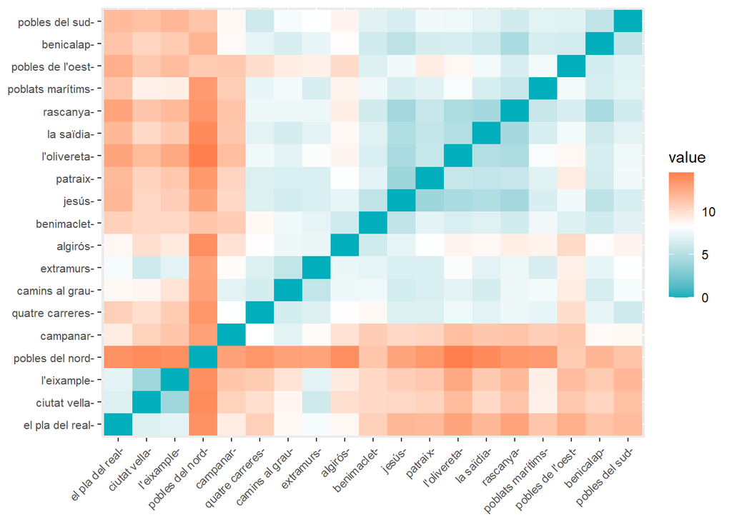

```r
midist = get_dist(data, stand = FALSE, method = "euclidean")

fviz_dist(midist, show_labels = TRUE, lab_size = 8,
          gradient = list(low = "#00AFBB", mid = "white", high = "#FC4E07"))
```

```r
set.seed(100)
myN = c(2, 6, 10, 14)
myhopkins = NULL
myseed = sample(1:1000, 10)
for (i in myN) {
  for (j in myseed) {
    tmp = get_clust_tendency(data = data, n = i, graph = FALSE, seed = j)
    myhopkins = c(myhopkins, tmp$hopkins_stat)
  }
}
summary(myhopkins)
```

```
##    Min. 1st Qu.  Median    Mean 3rd Qu.    Max.
##  0.5374  0.5914  0.6093  0.6147  0.6431  0.6778
```

El estadístico de Hopkins nos confirma que hay una tendencia de agrupamiento moderada, puesto que ha sido calculado para diferentes valores de m (n en la función) y con diferentes semillas aleatorias y sus valores oscilan entre 0.54 y 0.68.

## 6.3 Modelos jerárquicos

En primer lugar, aplicaremos modelos jerárquicos, probando por ejemplo el método de Ward y el método de la media. En principio, exploraremos la opción de k=3 para el número de clusters, tal como observábamos en el mapa de color, aunque luego aplicaremos otros criterios para estimar el número óptimo de clusters.

### 6.3.1 Método de Ward

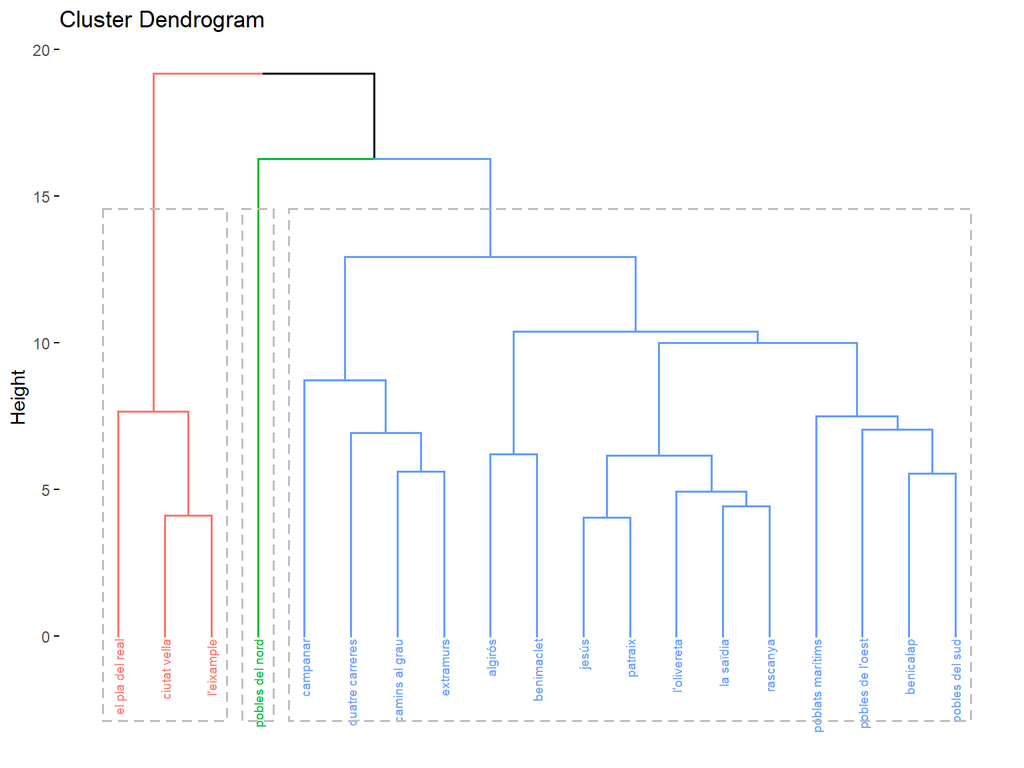

```r
#Le damos la matriz de distancia, no los datos originales. Podemos elegir la distancia que queramos.
clust1 <- hclust(midist, method="ward.D2")

#Elegimos el nº óptimo de clústers
grupos1 <- cutree(clust1, k=3)
fviz_dend(clust1, k = 3,
          cex = 0.5, color_labels_by_k = TRUE,
          rect = TRUE) # dibujar rectángulos
```

```r
#Me dice cuántos elementos han caído en cada clúster
table(grupos1)
```

```
## grupos1
##  1  2  3
## 15  3  1
```

### 6.3.2 Método de la media

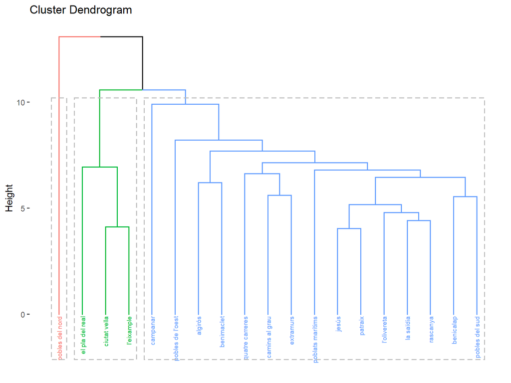

```r
clust2 <- hclust(midist, method="average")
grupos2 = cutree(clust2, k = 3)
fviz_dend(clust2, k = 3,
          cex = 0.5,
          color_labels_by_k = TRUE, # colorear etiquetas por grupo
          rect = TRUE) # dibujar rectángulos
```

```r
table(grupos2)
```

```
## grupos2
##  1  2  3
## 15  3  1
```

### 6.3.3 Método de la mediana

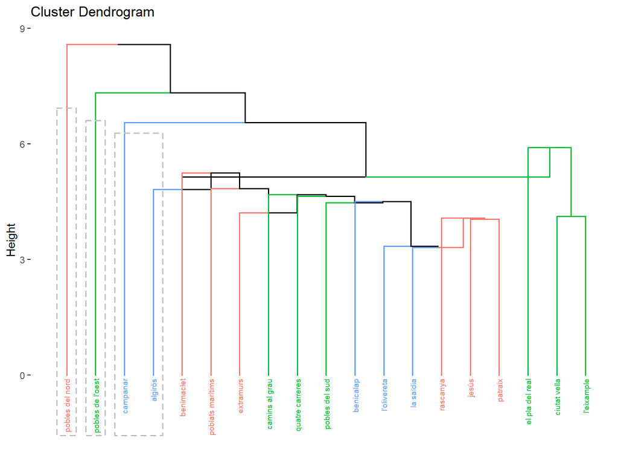

```r
clust3 <- hclust(midist, method="median")
grupos3 = cutree(clust3, k = 3)
fviz_dend(clust3, k = 3,
          cex = 0.5,
          color_labels_by_k = TRUE, # colorear etiquetas por grupo
          rect = TRUE) # dibujar rectángulos
```

```r
table(grupos3)
```

```
## grupos3
##  1  2  3
## 17  1  1
```

### 6.3.4 Método del Centroide

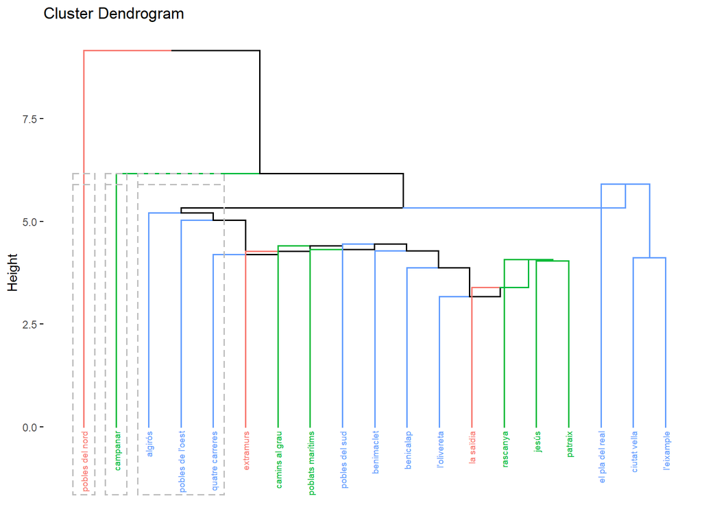

```r
clust4 <- hclust(midist, method="centroid")
grupos4 = cutree(clust4, k = 3)
fviz_dend(clust4, k = 3,
          cex = 0.5,
          color_labels_by_k = TRUE, # colorear etiquetas por grupo
          rect = TRUE) # dibujar rectángulos
```

```r
table(grupos4)
```

```
## grupos4
##  1  2  3
## 17  1  1
```

Para obtener el número de clusters óptimo para este algoritmo, podemos aplicar distintos criterios como se observa a continuación. Descartamos el método de GAP, porque los resultados no eran orientativos ni útiles.

### 6.3.5 Número óptimo de clusters Ward

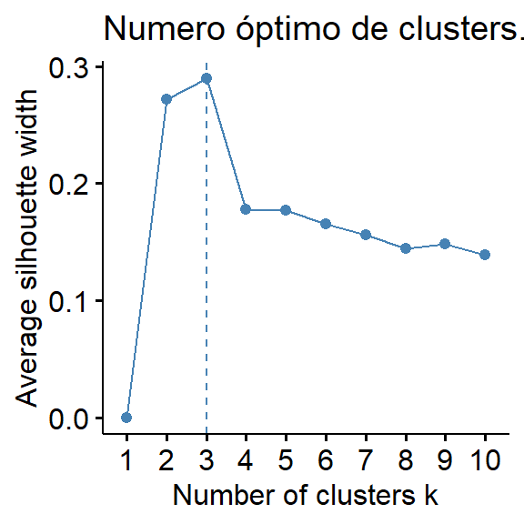

```r
#Coeficiente de Silhoeutte
fviz_nbclust(x = data, FUNcluster = hcut, method = "silhouette", hc_method = "ward.D2",
             k.max = 10, verbose = FALSE, hc_metric = "euclidean") +
  labs(title = "Numero óptimo de clusters.")
```

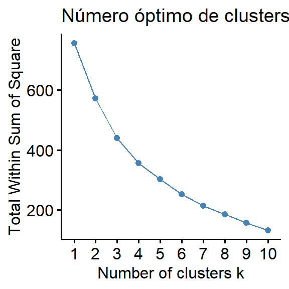

```r
#WSS
fviz_nbclust(x = data, FUNcluster = hcut, method = "wss", hc_method = "ward.D2",
             k.max = 10, verbose = FALSE, hc_metric = "euclidean") +
  labs(title = "Número óptimo de clusters")
```

### 6.3.6 Número óptimo de clusters Media

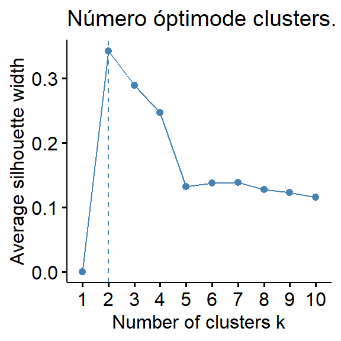

```r
#Coeficiente de Silhoeutte
fviz_nbclust(x = data, FUNcluster = hcut, method = "silhouette", hc_method = "average",
             k.max = 10, verbose = FALSE, hc_metric = "euclidean") +
  labs(title = "Número óptimode clusters.")
```

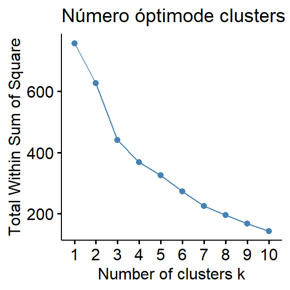

```r
#WSS
fviz_nbclust(x = data, FUNcluster = hcut, method = "wss", hc_method = "average",
             k.max = 10, verbose = FALSE, hc_metric = "euclidean") +
  labs(title = "Número óptimode clusters")
```

### 6.3.7 Número óptimo de clusters Mediana

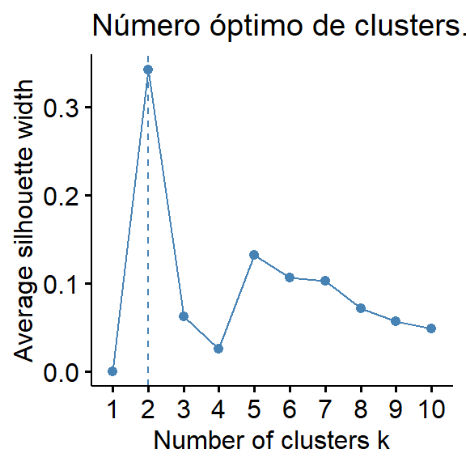

```r
#Coeficiente de Silhoeutte
fviz_nbclust(x = data, FUNcluster = hcut, method = "silhouette", hc_method = "median",
             k.max = 10, verbose = FALSE, hc_metric = "euclidean") +
  labs(title = "Número óptimo de clusters.")
```

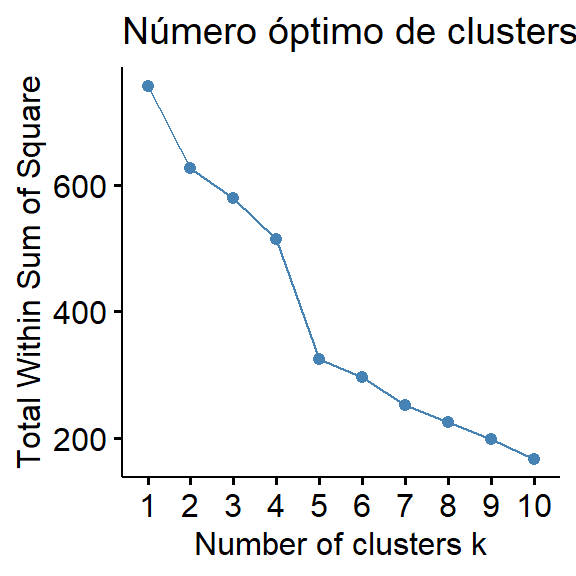

```r
#WSS
fviz_nbclust(x = data, FUNcluster = hcut, method = "wss", hc_method = "median",
             k.max = 10, verbose = FALSE, hc_metric = "euclidean") +
  labs(title = "Número óptimo de clusters")
```

### 6.3.8 Número óptimo de clusters Centroide

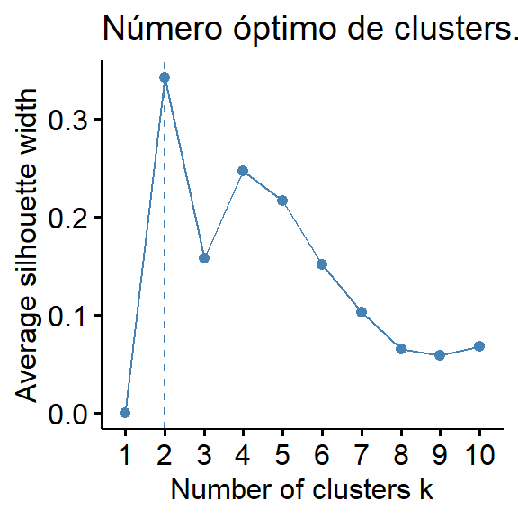

```r
#Coeficiente de Silhoeutte
fviz_nbclust(x = data, FUNcluster = hcut, method = "silhouette", hc_method = "centroid",
             k.max = 10, verbose = FALSE, hc_metric = "euclidean") +
  labs(title = "Número óptimo de clusters.")
```

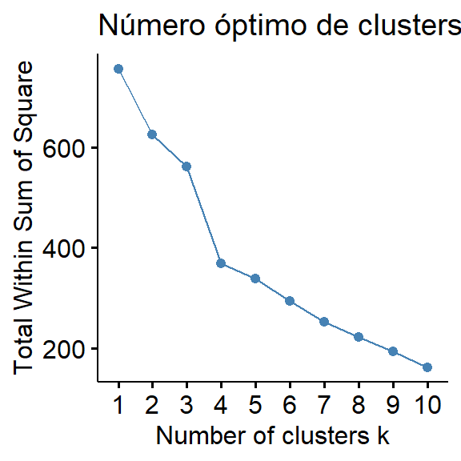

```r
#WSS
fviz_nbclust(x = data, FUNcluster = hcut, method = "wss", hc_method = "centroid",
             k.max = 10, verbose = FALSE, hc_metric = "euclidean") +
  labs(title = "Número óptimo de clusters")
```

```r
grupos1c <- cutree(clust1, k=3)
table(grupos1c)
```

```
## grupos1c
##  1  2  3
## 15  3  1
```

```r
grupos2b <- cutree(clust2, k=3)
table(grupos2b)
```

```
## grupos2b
##  1  2  3
## 15  3  1
```

```r
grupos3b <- cutree(clust3, k=3)
table(grupos3b)
```

```
## grupos3b
##  1  2  3
## 17  1  1
```

```r
grupos4b <- cutree(clust4, k=3)
table(grupos4b)
```

```
## grupos4b
##  1  2  3
## 17  1  1
```

Como se puede observar, los método de la mediana y del centroide los descartamos, ya que sus resultados no tienen sentido. Tenemos 2 clústers con un único elemento y 1 clúster con 17 elementos (distritos).

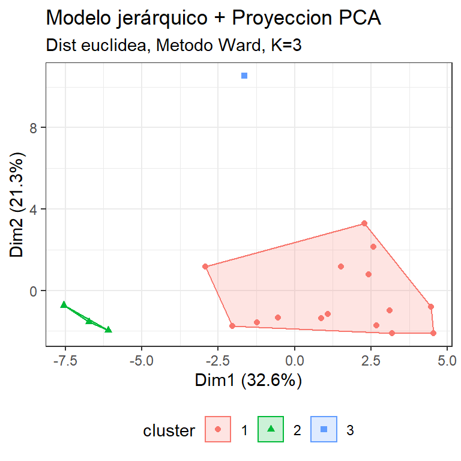

```r
#Coloreados por el clúster al que pertenecen
fviz_cluster(object = list(data=data, cluster=grupos1c), stand = FALSE,
             ellipse.type = "convex", geom = "point", show.clust.cent = FALSE,
             labelsize = 8)  +
  labs(title = "Modelo jerárquico + Proyeccion PCA",
       subtitle = "Dist euclidea, Metodo Ward, K=3") +
  theme_bw() +
  theme(legend.position = "bottom")
```

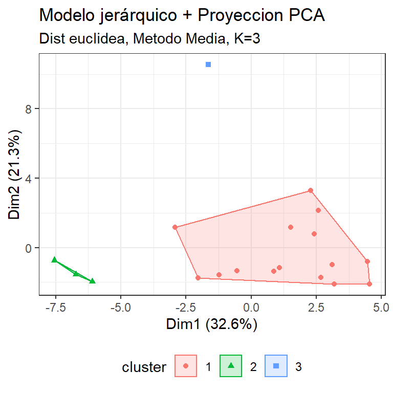

```r
#Coloreados por el clúster al que pertenecen
fviz_cluster(object = list(data=data, cluster=grupos2b), stand = FALSE,
             ellipse.type = "convex", geom = "point", show.clust.cent = FALSE,
             labelsize = 8)  +
  labs(title = "Modelo jerárquico + Proyeccion PCA",
       subtitle = "Dist euclidea, Metodo Media, K=3") +
  theme_bw() +
  theme(legend.position = "bottom")
```

## 6.4 Métodos de partición

### 6.4.1 K-media

En primer lugar, aplicaremos el método de k-medias. En este algoritmo es necesario determinar a priori el número de clusters. Lo fijaremos en 3 porque vemos que es el número óptimo de clusters

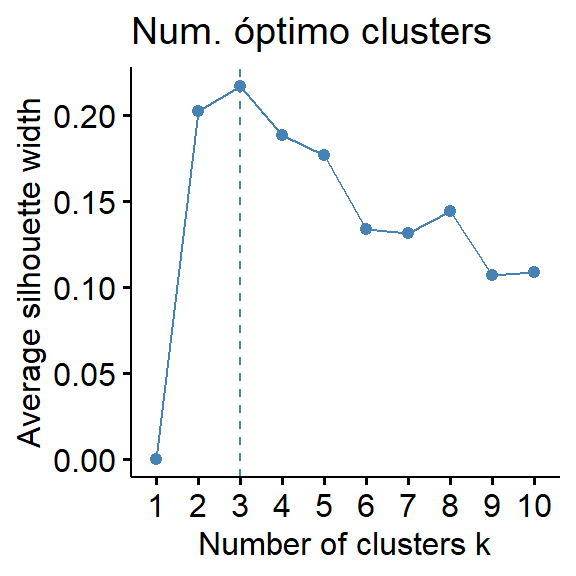

```r
fviz_nbclust(x = data, FUNcluster = kmeans, method = "silhouette",
             k.max = 10, verbose = FALSE) +
  labs(title = "Num. óptimo clusters")
```

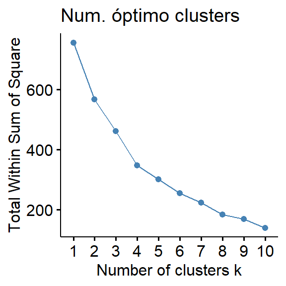

```r
fviz_nbclust(x = data, FUNcluster = kmeans, method = "wss",
             k.max = 10, verbose = FALSE) +
  labs(title = "Num. óptimo clusters")
```

```r
set.seed(100)
clust3 <- kmeans(data, centers = 3, nstart = 20)
table(clust3$cluster)
```

```
##
##  1  2  3
##  1  7 11
```

```r
which(clust3$cluster == 2)
```

```
##         algirós  camins al grau        campanar    ciutat vella el pla del real
##               1               4               5               6               7
##       extramurs      l'eixample
##               8              10
```

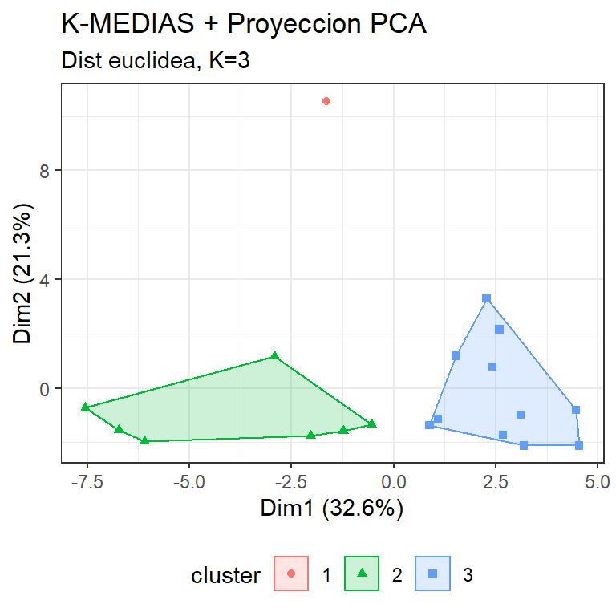

```r
fviz_cluster(object = list(data=data, cluster=clust3$cluster), stand = FALSE,
             ellipse.type = "convex", geom = "point", show.clust.cent = FALSE,
             labelsize = 8)  +
  labs(title = "K-MEDIAS + Proyeccion PCA",
       subtitle = "Dist euclidea, K=3") +
  theme_bw() +
  theme(legend.position = "bottom")
```

### 6.4.2 K-medoides

Dada la existencia de anómalos, vamos a probar como última opción el método de los k-medoides que, en teoría, debería ser más robusto frente a los valores atípicos.

En este algoritmo también es necesario determinar a priori el número de clusters. Por los mismos motivos que antes (ver las gráficas siguientes y el mapa de color), lo fijaremos en 3.

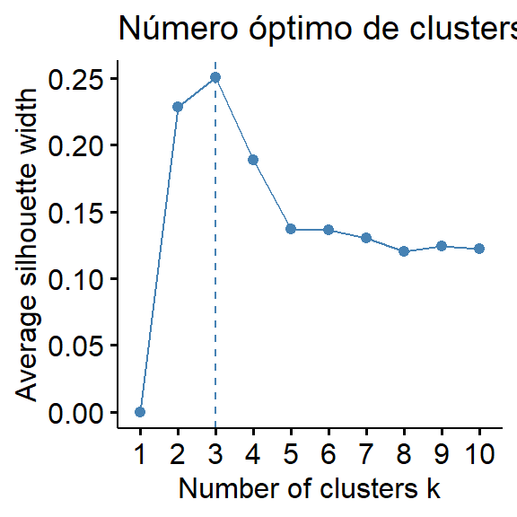

```r
fviz_nbclust(x = data, FUNcluster = pam, method = "silhouette",
             k.max = 10, verbose = FALSE) +
  labs(title = "Número óptimo de clusters")
```

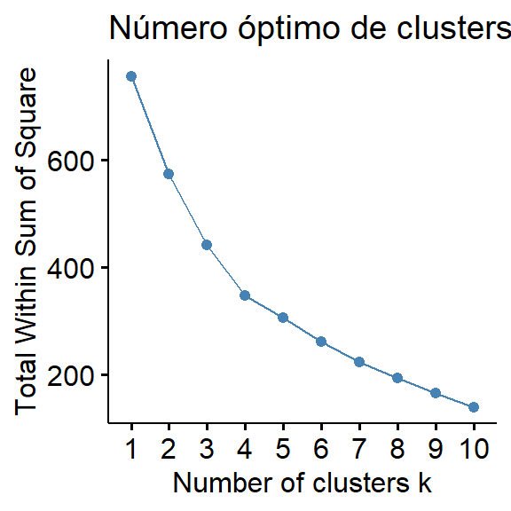

```r
fviz_nbclust(x = data, FUNcluster = pam, method = "wss",
             k.max = 10, verbose = FALSE) +
  labs(title = "Número óptimo de clusters")
```

```r
clust4 <- pam(data, k = 3)
table(clust4$clustering)
```

```
##
##  1  2  3
## 14  4  1
```

Veamos a partir del gráfico de scores del PCA cómo se han agrupado los datos y dónde están los valores anómalos.

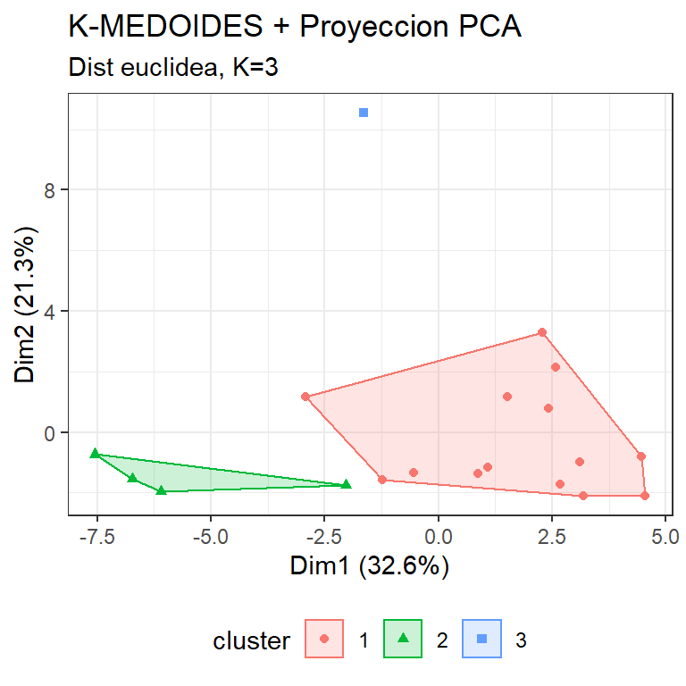

```r
fviz_cluster(object = list(data=data, cluster=clust4$clustering), stand = FALSE,
             ellipse.type = "convex", geom = "point", show.clust.cent = FALSE,
             labelsize = 8)  +
  labs(title = "K-MEDOIDES + Proyeccion PCA",
       subtitle = "Dist euclidea, K=3") +
  theme_bw() +
  theme(legend.position = "bottom")
```